# Appendix C: Analyses of incubation duration and hatching success on Bald Head Island, 1991-2023

Companion to *Recent increases in male sea turtle hatchling production on a North Carolina, USA beach despite a warming climate

Dr. Matt Ware

University of North Carolina Wilmington Center for Marine Science  
warem@uncw.edu

Paul Hillbrand

Bald Head Island Conservancy  
seaturtle@bhic.org

Ali Johnson

Bald Head Island Conservancy  
alijohnson0123@gmail.com

Dr. Stephanie Kamel

University of North Carolina Wilmington Center for Marine Science  
kamels@uncw.edu

Dr. Beth Darrow

Bald Head Island Conservancy  
darrow@bhic.org

2024-02-13

# 1 DESCRIPTION

Environmental conditions play a critical role in sea turtle embryonic development, controlling incubation temperature, moisture, gas exchange, salinity, and other variables to which the developing embryos must respond. Temperature, in particular, has a long-established link to hatchling sex ratios and mortality rates. The role of moisture from either waves or rainfall has been gaining increased attention in light of climate change concerns as a potential means to mediate feminization and mortality issues at tropical beaches.

Reneker and Kamel (2016a) investigated loggerhead turtle incubation temperature trends on Bald Head Island from 1991 to 2015 and extrapolated these values to hatchling sex ratios. During the peak of the nesting season (June - August), they reported an increasing trend in mean temperature (+0.09$^\circ C\ y^{-1}$) and a decreasing trend in total precipitation (-5.35 mm y<sup>-1</sup>). Incubation durations demonstrated a significant declining trend through the 25-yr dataset (n = 1347 *C. caretta* nests) with durations dropping from 59.2 $\pm$ 0.4 days in 1991 to 52.5 $\pm$ 0.5 days in 2015. Such averages correspond to 55% and 88% female hatchlings, respectively. Despite an increasing trend in air temperature and decreasing trend in precipitation during the same time period, the date of first nesting and hatching success showed no significant temporal trends. Reneker and Kamel (2016b) noted a significant maternal identity effect among repeat nesters which dominated any other factor.

However, since the publication of these two manuscripts, incubation durations - and therefore estimated male hatchling production - has increased despite a continued warming trend. A range of environmental, behavioral, and physiological variables were investigated to determine why.

**Reneker J, Kamel S (2016a) Climate change increases the production of female hatchlings at a northern sea turtle rookery. Ecology 97: 3257-3264. DOI: https://doi.org/10.1002/ecy.1603**

**Reneker J, Kamel S (2016b) The Maternal Legacy: Female identity predicts offspring sex ratio in the loggerhead sea turtle. Scientific Reports 6: 29237. DOI: https://doi.org/10.1038/srep29237.**

# 2 LIBRARIES AND DATA IMPORT

The following libraries were used throughout the subsequent analyses.

```r
library(datetimeutils)
library(DHARMa)
library(dplyr)
library(emmeans)
library(ggplot2)
library(glmmTMB)
library(janitor)
library(knitr)
library(mgcv)
library(MuMIn)
library(psych)
library(readxl)
library(report)
```

A meteorological record for Bald Head Island was generated in Appendix A. Maximum air temperature is available starting in 1991 with average air temperature and precipitation available since 2002.

Nesting data on Bald Head Island since 1991 includes the date the nest was laid, any disturbances including predation and wave overwash or erosion (i.e., washout), the date the nest hatched, incubation duration, clutch size, hatching and emergence success, beach zone, alongshore and cross-shore nest placement, nest elevation, and maternal identity.

# 3 METEOROLOGY DURING INCUBATION

The meteorological data utilized in Reneker and Kamel (2016a) is no longer available at the link provided in the manuscript and the GPS coordinates do not correspond to any recent weather station location. For this follow-up, daily meteorological data coincident with each nest was integrated based on available data from several weather stations either on or in proximity to Bald Head Island. Full meteorological data (i.e., Max/Min/Avg air temperature, Precipitation, Wind Speed/Direction, Maximum Solar Radiation) for the island is available starting 24 June 2015 from stations monitored by North Carolina State University and the State Climate Office. All variables except solar radiation are available starting 24 February 2002 from the Brunswick Airport. Average air temperature begins 18 January 2002 from Sunny Point Military Terminal, and Max/Min air temperature is available for the full observed date range from the Southport COOP.

After appending meteorological conditions coincident with each nest’s incubation, outliers experiencing extreme mean/max daily air temperatures or total precipitation were removed.

Average meteorology experienced by Bald Head Island nests, 1991 - 2023

| year | mean_air_temp | mean_max_air | mean_total_precip | N |
| --- | --- | --- | --- | --- |
| 1991 | NA | 28.2 | NA | 115 |
| 1992 | NA | 27.5 | NA | 88 |
| 1993 | NA | 28.5 | NA | 62 |
| 1994 | NA | 26.9 | NA | 90 |
| 1995 | NA | 27.7 | NA | 71 |
| 1996 | NA | 27.1 | NA | 82 |
| 1997 | NA | 27.2 | NA | 67 |
| 1998 | NA | 28.0 | NA | 77 |
| 1999 | NA | 27.7 | NA | 107 |
| 2000 | NA | 26.9 | NA | 45 |
| 2001 | NA | 26.7 | NA | 71 |
| 2002 | 27.2 | 30.0 | 118.4 | 77 |
| 2003 | 28.0 | 30.5 | 22.4 | 56 |
| 2004 | 26.3 | 29.0 | 19.2 | 33 |
| 2005 | 27.2 | 30.0 | 241.4 | 35 |
| 2006 | 24.7 | 27.6 | 150.9 | 41 |
| 2007 | 24.9 | 28.0 | 121.6 | 34 |
| 2008 | 26.7 | 30.9 | 130.2 | 78 |
| 2009 | 27.0 | 29.9 | 139.8 | 28 |
| 2010 | 27.0 | 30.2 | 81.0 | 57 |
| 2011 | 27.1 | 29.9 | 280.2 | 63 |
| 2012 | 26.0 | 29.2 | 227.0 | 62 |
| 2013 | 26.4 | 29.3 | 206.4 | 83 |
| 2014 | 26.2 | 29.0 | 314.8 | 32 |
| 2015 | 27.4 | 30.7 | 155.9 | 92 |
| 2016 | 28.3 | 31.7 | 240.5 | 99 |
| 2017 | 27.0 | 30.3 | 210.0 | 38 |
| 2018 | 27.4 | 30.7 | 325.0 | 52 |
| 2019 | 27.4 | 30.9 | 195.5 | 168 |
| 2020 | 27.9 | 31.4 | 192.5 | 111 |
| 2021 | 27.3 | 30.9 | 244.3 | 89 |
| 2022 | 27.5 | 30.7 | 238.6 | 145 |
| 2023 | 27.6 | 30.8 | 173.5 | 121 |

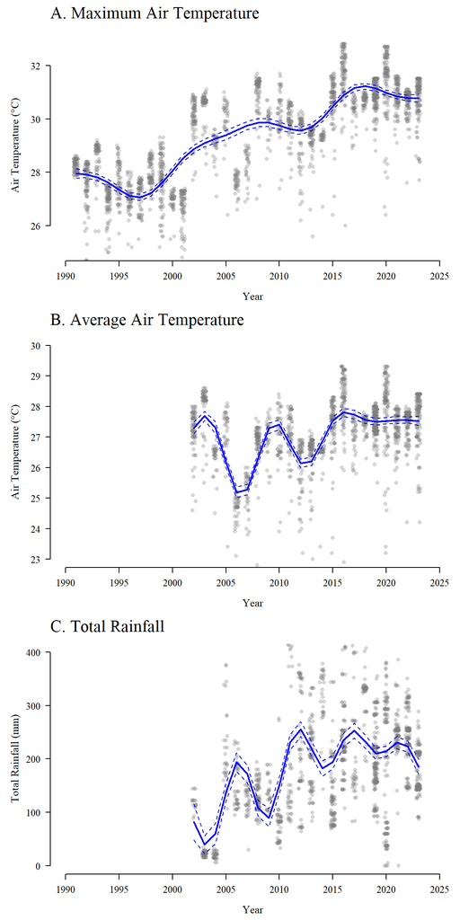

## 3.1 Meteorological Trends

**Average Daily Maximum Air Temperature**

All loggerhead nests on Bald Head Island have been experiencing a significantly increasing trend in average daily maximum air temperatures (GAM p << 0.001, +0.129$^\circ C\ yr^{-1}$).

```
##
## Family: gaussian
## Link function: identity
##
## Formula:
## mean_max_air ~ s(year)
##
## Parametric coefficients:
##             Estimate Std. Error t value Pr(>|t|)
## (Intercept) 29.46951    0.01816    1623   <2e-16 ***
## ---
## Signif. codes:  0 '***' 0.001 '**' 0.01 '*' 0.05 '.' 0.1 ' ' 1
##
## Approximate significance of smooth terms:
##           edf Ref.df     F p-value
## s(year) 8.803  8.988 758.5  <2e-16 ***
## ---
## Signif. codes:  0 '***' 0.001 '**' 0.01 '*' 0.05 '.' 0.1 ' ' 1
##
## R-sq.(adj) =  0.746   Deviance explained = 74.7%
## GCV = 0.76797  Scale est. = 0.76473   n = 2319
```

```
## [1] "Linear estimation of maximum air temperature (°C) increase per year: 0.129"
```

**Average Daily Mean Air Temperature**

Average daily mean air temperatures have been increasing as well, though at a slower pace (+0.030 $^\circ C\ yr^{-1}$) and with notable oscillations (GAM p << 0.001).

```
##
## Family: gaussian
## Link function: identity
##
## Formula:
## mean_avg_air ~ s(year)
##
## Parametric coefficients:
##             Estimate Std. Error t value Pr(>|t|)
## (Intercept) 27.36415    0.01725    1586   <2e-16 ***
## ---
## Signif. codes:  0 '***' 0.001 '**' 0.01 '*' 0.05 '.' 0.1 ' ' 1
##
## Approximate significance of smooth terms:
##           edf Ref.df     F p-value
## s(year) 8.961  8.999 67.94  <2e-16 ***
## ---
## Signif. codes:  0 '***' 0.001 '**' 0.01 '*' 0.05 '.' 0.1 ' ' 1
##
## R-sq.(adj) =  0.293   Deviance explained = 29.7%
## GCV = 0.44036  Scale est. = 0.43737   n = 1470
```

```
## [1] "Linear estimation of maximum air temperature (°C) increase per year: 0.03"
```

**Average Total Precipitation**

Average total precipitation during incubation has also increased (+6.69 mm y<sup>-1</sup>), but with substantial oscillation (GAM p << 0.001).

```
##
## Family: gaussian
## Link function: identity
##
## Formula:
## total_precip ~ s(year)
##
## Parametric coefficients:
##             Estimate Std. Error t value Pr(>|t|)
## (Intercept)  187.107      2.007   93.24   <2e-16 ***
## ---
## Signif. codes:  0 '***' 0.001 '**' 0.01 '*' 0.05 '.' 0.1 ' ' 1
##
## Approximate significance of smooth terms:
##          edf Ref.df     F p-value
## s(year) 8.98      9 79.12  <2e-16 ***
## ---
## Signif. codes:  0 '***' 0.001 '**' 0.01 '*' 0.05 '.' 0.1 ' ' 1
##
## R-sq.(adj) =  0.333   Deviance explained = 33.7%
## GCV = 5738.7  Scale est. = 5698.2    n = 1415
```

```
## [1] "Linear estimation of total precipitation (mm) increase per year: 6.691"
```

## 3.2 Five-Year Averages

Five-year moving averages are presented to smooth out interannual variability and provide additional data for use in subsequent analyses.

5-Year Averages of Meteorological Conditions on Bald Head Island

| Year Start | Year End | Mean Avg Temp | SD Avg Temp | Mean Max Temp | SD Max Temp | Mean Total Rain | SD Total Rain |
| --- | --- | --- | --- | --- | --- | --- | --- |
| 1991 | 1995 | NA | NA | 27.7 | 0.9 | NA | NA |
| 1992 | 1996 | NA | NA | 27.5 | 0.9 | NA | NA |
| 1993 | 1997 | NA | NA | 27.4 | 0.9 | NA | NA |
| 1994 | 1998 | NA | NA | 27.3 | 0.7 | NA | NA |
| 1995 | 1999 | NA | NA | 27.5 | 0.8 | NA | NA |
| 1996 | 2000 | NA | NA | 27.4 | 0.8 | NA | NA |
| 1997 | 2001 | NA | NA | 27.4 | 0.9 | NA | NA |
| 1998 | 2002 | NA | NA | 28.0 | 1.4 | NA | NA |
| 1999 | 2003 | NA | NA | 28.4 | 1.7 | NA | NA |
| 2000 | 2004 | NA | NA | 28.7 | 1.7 | NA | NA |
| 2001 | 2005 | NA | NA | 29.1 | 1.6 | NA | NA |
| 2002 | 2006 | 26.9 | 1.3 | 29.6 | 1.2 | 102.0 | 101.1 |
| 2003 | 2007 | 26.4 | 1.6 | 29.1 | 1.4 | 103.8 | 97.6 |
| 2004 | 2008 | 26.1 | 1.4 | 29.4 | 1.6 | 133.7 | 80.4 |
| 2005 | 2009 | 26.1 | 1.4 | 29.5 | 1.7 | 152.0 | 66.1 |
| 2006 | 2010 | 26.2 | 1.4 | 29.6 | 1.6 | 123.5 | 41.8 |
| 2007 | 2011 | 26.6 | 1.2 | 30.0 | 1.3 | 157.8 | 111.9 |
| 2008 | 2012 | 26.7 | 1.0 | 30.1 | 1.1 | 177.7 | 118.4 |
| 2009 | 2013 | 26.6 | 0.9 | 29.6 | 0.8 | 199.2 | 117.6 |
| 2010 | 2014 | 26.5 | 1.0 | 29.5 | 0.9 | 217.9 | 121.2 |
| 2011 | 2015 | 26.7 | 1.1 | 29.8 | 1.1 | 220.5 | 123.4 |
| 2012 | 2016 | 27.1 | 1.3 | 30.3 | 1.4 | 215.8 | 101.3 |
| 2013 | 2017 | 27.3 | 1.2 | 30.5 | 1.3 | 213.2 | 100.2 |
| 2014 | 2018 | 27.5 | 1.1 | 30.8 | 1.2 | 233.5 | 112.3 |
| 2015 | 2019 | 27.6 | 0.8 | 31.0 | 0.8 | 213.5 | 97.4 |
| 2016 | 2020 | 27.7 | 0.9 | 31.1 | 0.9 | 219.9 | 94.2 |
| 2017 | 2021 | 27.5 | 0.7 | 31.0 | 0.8 | 220.2 | 91.2 |
| 2018 | 2022 | 27.5 | 0.7 | 30.9 | 0.7 | 225.6 | 82.4 |
| 2019 | 2023 | 27.5 | 0.7 | 30.9 | 0.8 | 207.5 | 72.8 |

# 4 INCUBATION DURATION

In the presented analysis, 1,186 nests (50.3%) were removed from the Bald Head Island loggerhead nest dataset due to relocation, predation, invasion by sea oat roots (*Uniola paniculata*), wave wash-over, wave wash-out, failure of the offspring to hatch from the egg or emerge from the nest, or missing lay date or incubation durations. No nests were reported to be scattered by another nesting female or poached. This left 1,170 nests from 1991 - 2023 available for analysis.

Incubation durations between *in situ* and relocated nests which were otherwise undisturbed were significantly different (Relocated nests 1.4 days shorter on average, p << 0.001), hence the separation by relocation status mentioned above. However, relocation status alone only explains 1.9% of the observed variation in incubation durations.

```
##
## Call:
## lm(formula = incubation_duration ~ in_situ_relocated, data = BHI_Undist_IncDur)
##
## Residuals:
##      Min       1Q   Median       3Q      Max
## -14.9567  -2.9567   0.0433   3.0433  18.4624
##
## Coefficients:
##                            Estimate Std. Error t value Pr(>|t|)
## (Intercept)                 56.9567     0.1711 332.925  < 2e-16 ***
## in_situ_relocatedRelocated  -1.4191     0.2830  -5.014 6.11e-07 ***
## ---
## Signif. codes:  0 '***' 0.001 '**' 0.01 '*' 0.05 '.' 0.1 ' ' 1
##
## Residual standard error: 4.793 on 1235 degrees of freedom
## Multiple R-squared:  0.01995,    Adjusted R-squared:  0.01916
## F-statistic: 25.14 on 1 and 1235 DF,  p-value: 6.106e-07
```

Overall, the current Bald Head Island dataset approximates a normal distribution.

```
##    vars    n  mean   sd median trimmed  mad min max range skew kurtosis   se
## X1    1 1170 57.87 4.95     58   57.68 4.45  42  83    41  0.5     1.12 0.14
```

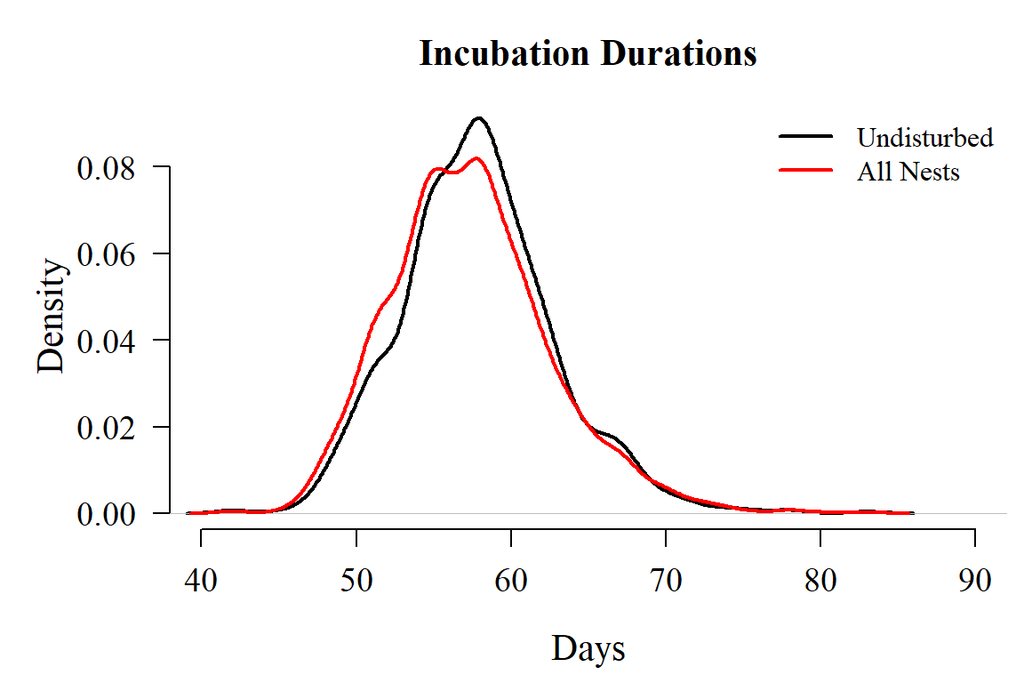

Incubation durations are variable from year to year. Observed annual mean incubation durations have ranged from 52.0 $\pm$ 0.7 days (2006) to 63.0 $\pm$ 4.4 days in 1996. The 2023 average was 55.1 $\pm$ 3.8 days.

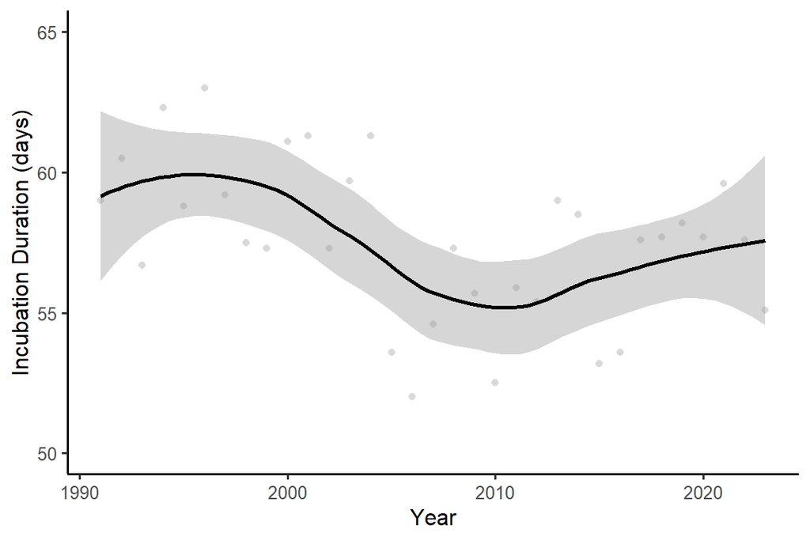

Average Incubation Durations on Bald Head Island by Year

| year | mean | sd | n |
| --- | --- | --- | --- |
| 1991 | 59.0 | 3.8 | 99 |
| 1992 | 60.5 | 4.7 | 62 |
| 1993 | 56.7 | 2.8 | 46 |
| 1994 | 62.3 | 5.8 | 63 |
| 1995 | 58.8 | 6.4 | 35 |
| 1996 | 63.0 | 4.4 | 21 |
| 1997 | 59.2 | 3.9 | 58 |
| 1998 | 57.5 | 2.3 | 11 |
| 1999 | 57.3 | 7.2 | 24 |
| 2000 | 61.1 | 4.8 | 19 |
| 2001 | 61.3 | 4.4 | 30 |
| 2002 | 57.3 | 3.3 | 42 |
| 2003 | 59.7 | 3.6 | 39 |
| 2004 | 61.3 | 4.0 | 13 |
| 2005 | 53.6 | 2.8 | 19 |
| 2006 | 52.0 | 0.7 | 5 |
| 2007 | 54.6 | 3.7 | 10 |
| 2008 | 57.3 | 3.6 | 33 |
| 2009 | 55.7 | 3.6 | 6 |
| 2010 | 52.5 | 2.3 | 30 |
| 2011 | 55.9 | 4.4 | 27 |
| 2012 | 55.4 | 3.7 | 34 |
| 2013 | 59.0 | 4.3 | 43 |
| 2014 | 58.5 | 3.5 | 13 |
| 2015 | 53.2 | 5.0 | 53 |
| 2016 | 53.6 | 5.1 | 48 |
| 2017 | 57.6 | 3.6 | 28 |
| 2018 | 57.7 | 3.6 | 32 |
| 2019 | 58.2 | 4.0 | 51 |
| 2020 | 57.7 | 4.4 | 26 |
| 2021 | 59.6 | 3.8 | 35 |
| 2022 | 57.6 | 4.1 | 71 |
| 2023 | 55.1 | 3.8 | 44 |

Year is a significant variable with respect to incubation durations, but it is a poor descriptor as Year alone only explains 15.1% of the observed variance.

*Gaussian GAM*, $Duration = \beta_0 + f(Year) + \epsilon$

```
##
## Family: gaussian
## Link function: identity
##
## Formula:
## incubation_duration ~ s(year)
##
## Parametric coefficients:
##             Estimate Std. Error t value Pr(>|t|)
## (Intercept)  57.8744     0.1339   432.1   <2e-16 ***
## ---
## Signif. codes:  0 '***' 0.001 '**' 0.01 '*' 0.05 '.' 0.1 ' ' 1
##
## Approximate significance of smooth terms:
##           edf Ref.df     F p-value
## s(year) 8.738  8.979 22.28  <2e-16 ***
## ---
## Signif. codes:  0 '***' 0.001 '**' 0.01 '*' 0.05 '.' 0.1 ' ' 1
##
## R-sq.(adj) =  0.144   Deviance explained = 15.1%
## GCV = 21.166  Scale est. = 20.99     n = 1170
```

*The declining trend in Reneker and Kamel (2016) is not continued in the 2019 - 2023 Bald Head Island loggerhead nest data. The recent data is more in line with incubation durations from the mid-2000s.*

## 4.1 Five-Year Averages

To help smooth out this variability, 5-year moving averages are presented below.

5-Year Averages of Incubation Durations on Bald Head Island

| Year Start | Year End | Mean Duration | SD Duration |
| --- | --- | --- | --- |
| 1991 | 1995 | 59.6 | 5.0 |
| 1992 | 1996 | 60.2 | 5.4 |
| 1993 | 1997 | 59.9 | 5.3 |
| 1994 | 1998 | 60.5 | 5.4 |
| 1995 | 1999 | 59.2 | 5.4 |
| 1996 | 2000 | 59.6 | 5.0 |
| 1997 | 2001 | 59.5 | 4.9 |
| 1998 | 2002 | 58.8 | 5.0 |
| 1999 | 2003 | 59.1 | 4.8 |
| 2000 | 2004 | 59.7 | 4.2 |
| 2001 | 2005 | 58.7 | 4.4 |
| 2002 | 2006 | 57.7 | 4.2 |
| 2003 | 2007 | 57.5 | 4.7 |
| 2004 | 2008 | 56.4 | 4.3 |
| 2005 | 2009 | 55.5 | 3.7 |
| 2006 | 2010 | 54.8 | 3.7 |
| 2007 | 2011 | 55.2 | 4.0 |
| 2008 | 2012 | 55.3 | 3.9 |
| 2009 | 2013 | 56.0 | 4.5 |
| 2010 | 2014 | 56.2 | 4.5 |
| 2011 | 2015 | 55.9 | 4.9 |
| 2012 | 2016 | 55.4 | 5.2 |
| 2013 | 2017 | 55.7 | 5.2 |
| 2014 | 2018 | 55.2 | 5.0 |
| 2015 | 2019 | 55.7 | 5.0 |
| 2016 | 2020 | 56.7 | 4.6 |
| 2017 | 2021 | 58.2 | 3.9 |
| 2018 | 2022 | 58.1 | 4.0 |
| 2019 | 2023 | 57.6 | 4.2 |

## 4.2 Incubation Duration ~ f(Meteorological, Behavioral, and Maternal Variables)

To test which meteorological variables are important drivers of incubation duration, a nested model selection approach using AICc was employed. The full GAM includes average daily mean air temperature and average total precipitation experienced during incubation, as well as Year, Day Laid, Distance from the Ferry Port, Distance from the Dune Toe, Elevation, Clutch Size, and Maternal Identity as additional covariates:

*Gaussian GAM*,  
$Duration_i = \beta_0 + f_1(Air_{avg,i}) + f_2(Precip_i) + f_3(Year_i) + f_4(DayLaid_i) + f_5(DistFerry_i) +$  
$f_6(DistDune_i) +f_7(Elevation_i) + f_8(ClutchSize_i) + \beta_1(FemaleID_i) + \epsilon_i$

Average daily maximum air temperature was not included in the model because it is highly correlated (88.2%) with average air temperature. A model including maximum air temperature was 23.5 AICc points higher than a model using mean air temperatures, indicating mean air temperature is the more informative variable.

570 nests include observations for each of these variables. The best model includes all of these variables except maternal identity and cross-shore distance and explains 64% of the deviance. Removing any of the variables results in a significant increase in AICc.

```
##              mean_max_air mean_avg_air total_precip
## mean_max_air   1.00000000    0.8815893   0.01668226
## mean_avg_air   0.88158928    1.0000000  -0.10816113
## total_precip   0.01668226   -0.1081611   1.00000000
```

```
## [1] "Model with Mean Air Temp, AICc: 2910.73196823004"
```

```
## [1] "Model with Maximum Air Temp, AICc: 2934.26699338863"
```

```
## Global model call: mgcv::gam(formula = incubation_duration ~ s(mean_avg_air) + s(total_precip) +
##     s(year) + s(day_laid) + s(beach_distance_m) + s(dist_dune) +
##     s(dem_avg) + s(clutch_size) + factor(turtle_id), family = "gaussian",
##     data = BHI_Undist_IncDur_Full, na.action = "na.fail")
## ---
## Model selection table
##     (Int) s(bch_dstn_m) s(clt_siz) s(day_lad) s(dem_avg) s(dist_dun)
## 479 56.76             +          +          +          +
## 511 56.76             +          +          +          +           +
## 495 56.76             +          +          +                      +
## 475 56.76             +                     +          +
## 507 56.76             +                     +          +           +
## 463 56.76             +          +          +
## 491 56.76             +                     +                      +
##     s(men_avg_air) s(ttl_prc) s(yer) df    logLik   AICc delta weight
## 479              +          +      + 26 -1371.306 2797.7  0.00  0.715
## 511              +          +      + 33 -1364.936 2801.0  3.28  0.138
## 495              +          +      + 30 -1368.132 2801.9  4.17  0.089
## 475              +          +      + 25 -1375.468 2803.9  6.21  0.032
## 507              +          +      + 33 -1367.764 2806.2  8.52  0.010
## 463              +          +      + 25 -1376.583 2806.4  8.69  0.009
## 491              +          +      + 31 -1369.700 2807.2  9.49  0.006
## Models ranked by AICc(x)
```

*Potential issue with low sample size in 2002 (n = 4), 2006 (n = 5), 2007 (n = 9), and 2009 (n = 5)*

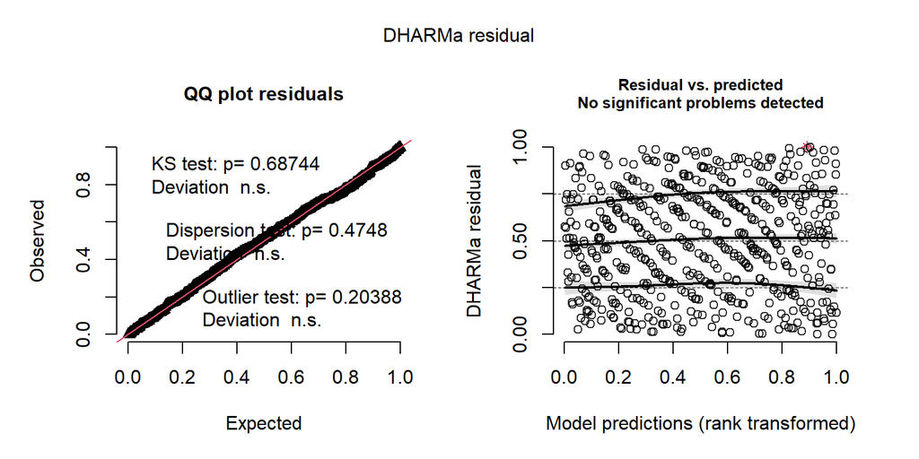

```
##
## Family: gaussian
## Link function: identity
##
## Formula:
## incubation_duration ~ s(mean_avg_air) + s(total_precip) + s(year) +
##     s(day_laid) + s(beach_distance_m) + +s(dem_avg) + s(clutch_size)
##
## Parametric coefficients:
##             Estimate Std. Error t value Pr(>|t|)
## (Intercept)  56.7649     0.1158   490.1   <2e-16 ***
## ---
## Signif. codes:  0 '***' 0.001 '**' 0.01 '*' 0.05 '.' 0.1 ' ' 1
##
## Approximate significance of smooth terms:
##                       edf Ref.df      F  p-value
## s(mean_avg_air)     1.123  1.231 45.625  < 2e-16 ***
## s(total_precip)     8.358  8.875 22.833  < 2e-16 ***
## s(year)             8.464  8.863  9.203  < 2e-16 ***
## s(day_laid)         3.307  4.199 54.025  < 2e-16 ***
## s(beach_distance_m) 1.000  1.000 56.504  < 2e-16 ***
## s(dem_avg)          1.000  1.000 10.993 0.000976 ***
## s(clutch_size)      1.000  1.000  8.372 0.003963 **
## ---
## Signif. codes:  0 '***' 0.001 '**' 0.01 '*' 0.05 '.' 0.1 ' ' 1
##
## R-sq.(adj) =  0.621   Deviance explained = 63.7%
## GCV = 8.0007  Scale est. = 7.6462    n = 570
```

Number of nests included in the above model per year

| Var1 | Freq |
| --- | --- |
| 2002 | 4 |
| 2003 | 31 |
| 2004 | 12 |
| 2005 | 17 |
| 2006 | 5 |
| 2007 | 9 |
| 2008 | 28 |
| 2009 | 5 |
| 2010 | 20 |
| 2011 | 19 |
| 2012 | 24 |
| 2013 | 36 |
| 2014 | 13 |
| 2015 | 44 |
| 2016 | 38 |
| 2017 | 26 |
| 2018 | 31 |
| 2019 | 45 |
| 2020 | 25 |
| 2021 | 31 |
| 2022 | 65 |
| 2023 | 42 |

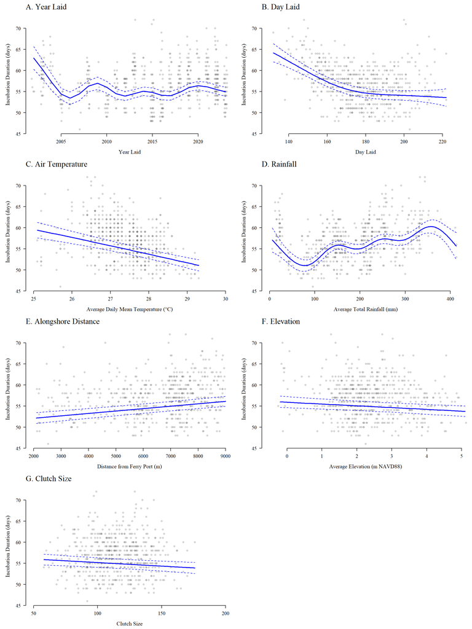

When scaled in a linear model for a more simple effect size comparison, average air temperature (-1.38) and precipitation (1.29) have comparable effect sizes but air temperature’s effect is stronger. Approximately 119mm of rainfall is needed to counteract 1$^\circ C$ of warming average air temperatures. Day Laid has a comparable effect size as air temperature and precipitation (-1.61) Alongshore distance has a relatively strong effect (1.12), and elevation (-0.46) and clutch size (-0.21) have small effects on incubation duration.

```
##                  Estimate Std. Error t value Pr(>|t|)
## (Intercept)       321.490     63.958   5.027    0.000
## mean_avg_air       -1.836      0.214  -8.587    0.000
## total_precip        0.014      0.002   6.670    0.000
## year               -0.101      0.032  -3.108    0.002
## day_laid           -0.092      0.009 -10.016    0.000
## beach_distance_m    0.001      0.000   7.138    0.000
## dem_avg            -0.469      0.157  -2.980    0.003
## clutch_size        -0.010      0.008  -1.306    0.192
```

```
##                    2.5 %  97.5 %
## (Intercept)      195.865 447.115
## mean_avg_air      -2.256  -1.416
## total_precip       0.010   0.019
## year              -0.164  -0.037
## day_laid          -0.110  -0.074
## beach_distance_m   0.000   0.001
## dem_avg           -0.779  -0.160
## clutch_size       -0.025   0.005
```

```
##                         Estimate Std. Error t value Pr(>|t|)
## (Intercept)               56.765      0.153 372.065    0.000
## scale(mean_avg_air)       -1.376      0.160  -8.587    0.000
## scale(total_precip)        1.287      0.193   6.670    0.000
## scale(year)               -0.609      0.196  -3.108    0.002
## scale(day_laid)           -1.612      0.161 -10.016    0.000
## scale(beach_distance_m)    1.124      0.157   7.138    0.000
## scale(dem_avg)            -0.462      0.155  -2.980    0.003
## scale(clutch_size)        -0.209      0.160  -1.306    0.192
```

```
##                          2.5 % 97.5 %
## (Intercept)             56.465 57.065
## scale(mean_avg_air)     -1.691 -1.061
## scale(total_precip)      0.908  1.666
## scale(year)             -0.993 -0.224
## scale(day_laid)         -1.929 -1.296
## scale(beach_distance_m)  0.815  1.433
## scale(dem_avg)          -0.767 -0.157
## scale(clutch_size)      -0.524  0.105
```

```
## [1] "It takes 119.2 mm of total precipitation, 2206.2 m of alongshore movement, or a 23.4-day shift\nearlier in the season to counteract 1°C of increased average air temperature."
```

## 4.3 Day Laid Exploration

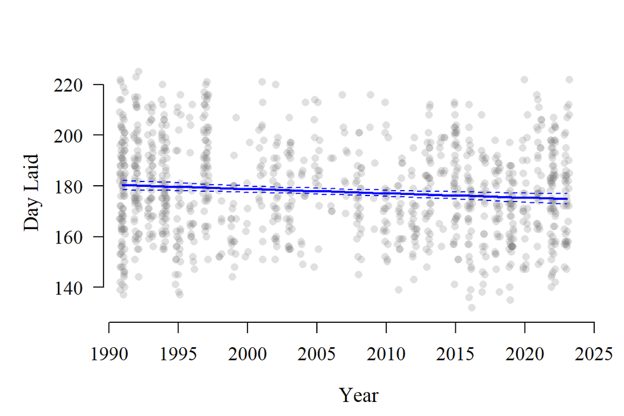

```
##
## Call:
## lm(formula = day_laid ~ year, data = BHI_IncDur_Clean)
##
## Residuals:
##     Min      1Q  Median      3Q     Max
## -44.078 -14.090  -0.657  13.070  47.115
##
## Coefficients:
##             Estimate Std. Error t value Pr(>|t|)
## (Intercept) 519.6470   101.3011   5.130 3.46e-07 ***
## year         -0.1704     0.0505  -3.375 0.000766 ***
## ---
## Signif. codes:  0 '***' 0.001 '**' 0.01 '*' 0.05 '.' 0.1 ' ' 1
##
## Residual standard error: 18.38 on 1033 degrees of freedom
## Multiple R-squared:  0.01091,    Adjusted R-squared:  0.009948
## F-statistic: 11.39 on 1 and 1033 DF,  p-value: 0.0007661
```

```
## [1] "Mean day laid 2003-2007: 180.6, Projected incubation duration: 54.6 days"
```

```
## [1] "Mean day laid 2019-2023: 175.7, Projected incubation duration: 55 days"
```

### 4.3.1 Date of First/Last Nesting and Season Length

The dates of the first and last nests laid were extracted for each year to investigate potential changes through time. The length of nesting season was calculated as the number of days between the first and last nest laid each year per island.

The earliest nest occurring in the Bald Head dataset was 3 May 2002 (day 123), whereas the latest was 9 September 2008 (day 253). In 2023, the season started on 16 May (day 136).

Dates of first and last nests laid each year and corresponding nesting season length for Bald Head Island

| year | first_nest | min_day | min_week | last_nest | max_day | max_week | nest_length |
| --- | --- | --- | --- | --- | --- | --- | --- |
| 1991 | 1991-05-17 | 137 | 20 | 1991-08-13 | 225 | 33 | 88 |
| 1992 | 1992-05-23 | 144 | 21 | 1992-08-12 | 225 | 33 | 81 |
| 1993 | 1993-05-27 | 147 | 22 | 1993-08-11 | 223 | 33 | 76 |
| 1994 | 1994-05-26 | 146 | 22 | 1994-08-09 | 221 | 33 | 75 |
| 1995 | 1995-05-17 | 137 | 20 | 1995-08-13 | 225 | 33 | 88 |
| 1996 | 1996-05-24 | 145 | 21 | 1996-08-14 | 227 | 33 | 82 |
| 1997 | 1997-05-28 | 148 | 22 | 1997-08-13 | 225 | 33 | 77 |
| 1998 | 1998-05-15 | 135 | 20 | 1998-08-10 | 222 | 33 | 87 |
| 1999 | 1999-05-22 | 142 | 21 | 1999-08-24 | 236 | 35 | 94 |
| 2000 | 2000-05-21 | 142 | 22 | 2000-08-22 | 235 | 35 | 93 |
| 2001 | 2001-05-21 | 141 | 21 | 2001-08-16 | 228 | 33 | 87 |
| 2002 | 2002-05-03 | 123 | 18 | 2002-08-11 | 223 | 33 | 100 |
| 2003 | 2003-05-17 | 137 | 20 | 2003-08-06 | 218 | 32 | 81 |
| 2004 | 2004-05-28 | 149 | 22 | 2004-08-09 | 222 | 33 | 73 |
| 2005 | 2005-05-28 | 148 | 22 | 2005-08-22 | 234 | 35 | 86 |
| 2006 | 2006-05-31 | 151 | 22 | 2006-08-13 | 225 | 33 | 74 |
| 2007 | 2007-05-30 | 150 | 22 | 2007-09-05 | 248 | 36 | 98 |
| 2008 | 2008-05-20 | 141 | 21 | 2008-09-09 | 253 | 37 | 112 |
| 2009 | 2009-05-31 | 151 | 23 | 2009-08-06 | 218 | 32 | 67 |
| 2010 | 2010-05-30 | 150 | 23 | 2010-08-15 | 227 | 34 | 77 |
| 2011 | 2011-05-19 | 139 | 21 | 2011-08-05 | 217 | 32 | 78 |
| 2012 | 2012-05-21 | 142 | 21 | 2012-08-09 | 222 | 32 | 80 |
| 2013 | 2013-05-28 | 148 | 22 | 2013-08-23 | 235 | 34 | 87 |
| 2014 | 2014-06-05 | 156 | 23 | 2014-09-09 | 252 | 37 | 96 |
| 2015 | 2015-05-20 | 140 | 21 | 2015-08-22 | 234 | 34 | 94 |
| 2016 | 2016-05-11 | 132 | 20 | 2016-08-30 | 243 | 36 | 111 |
| 2017 | 2017-05-18 | 138 | 20 | 2017-07-27 | 208 | 30 | 70 |
| 2018 | 2018-05-18 | 138 | 20 | 2018-07-31 | 212 | 31 | 74 |
| 2019 | 2019-05-15 | 135 | 20 | 2019-08-10 | 222 | 32 | 87 |
| 2020 | 2020-05-26 | 147 | 22 | 2020-08-21 | 234 | 34 | 87 |
| 2021 | 2021-05-26 | 146 | 22 | 2021-08-14 | 226 | 33 | 80 |
| 2022 | 2022-05-20 | 140 | 21 | 2022-08-11 | 223 | 33 | 83 |
| 2023 | 2023-05-16 | 136 | 20 | 2023-08-10 | 222 | 32 | 86 |

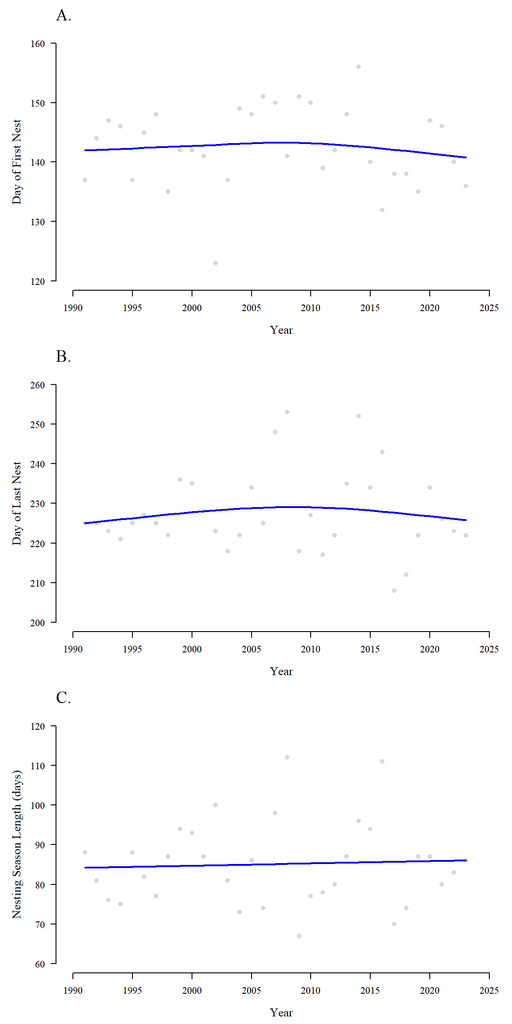

There is no statistically significant trend in the dates of first nest deposition, last nest deposition, or nesting season length. This is consistent with the results of Reneker and Kamel (2016a) for Bald Head Island. The addition of 2016-2023 data to their previous 1991-2015 data does not alter their observed pattern.

```
##
## Family: gaussian
## Link function: identity
##
## Formula:
## min_day ~ s(year)
##
## Parametric coefficients:
##             Estimate Std. Error t value Pr(>|t|)
## (Intercept)  142.455      1.176   121.1   <2e-16 ***
## ---
## Signif. codes:  0 '***' 0.001 '**' 0.01 '*' 0.05 '.' 0.1 ' ' 1
##
## Approximate significance of smooth terms:
##           edf Ref.df     F p-value
## s(year) 1.557  1.924 0.355   0.723
##
## R-sq.(adj) =  -0.00552   Deviance explained = 4.34%
## GCV = 49.464  Scale est. = 45.631    n = 33
```

```
##
## Family: gaussian
## Link function: identity
##
## Formula:
## max_day ~ s(year)
##
## Parametric coefficients:
##             Estimate Std. Error t value Pr(>|t|)
## (Intercept)  227.576      1.796   126.7   <2e-16 ***
## ---
## Signif. codes:  0 '***' 0.001 '**' 0.01 '*' 0.05 '.' 0.1 ' ' 1
##
## Approximate significance of smooth terms:
##           edf Ref.df     F p-value
## s(year) 1.555  1.921 0.469   0.605
##
## R-sq.(adj) =  0.00445   Deviance explained = 5.28%
## GCV =  115.4  Scale est. = 106.46    n = 33
```

```
##
## Family: gaussian
## Link function: identity
##
## Formula:
## nest_length ~ s(year)
##
## Parametric coefficients:
##             Estimate Std. Error t value Pr(>|t|)
## (Intercept)   85.121      1.866   45.61   <2e-16 ***
## ---
## Signif. codes:  0 '***' 0.001 '**' 0.01 '*' 0.05 '.' 0.1 ' ' 1
##
## Approximate significance of smooth terms:
##         edf Ref.df     F p-value
## s(year)   1      1 0.091   0.765
##
## R-sq.(adj) =  -0.0292   Deviance explained = 0.293%
## GCV = 122.35  Scale est. = 114.94    n = 33
```

**The start, end, and length of the nesting season have not changed, but turtles are nesting more frequently earlier in the season.**

## 4.4 Beach Distance Exploration

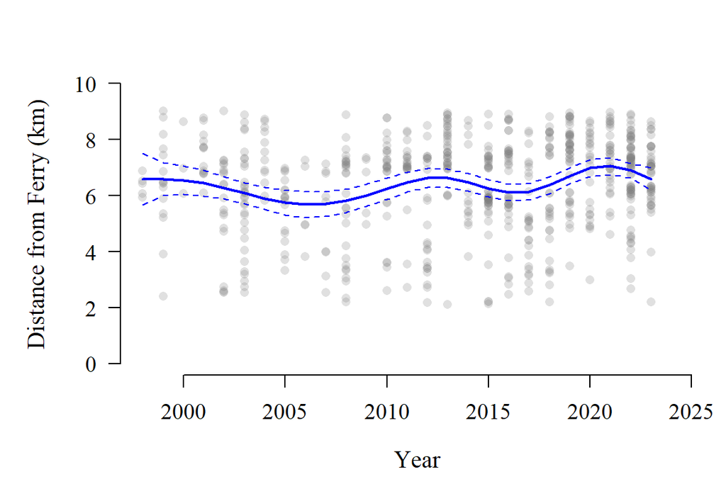

```
##
## Call:
## lm(formula = beach_distance_m ~ year, data = BHI_IncDur_Clean)
##
## Residuals:
##     Min      1Q  Median      3Q     Max
## -4515.4  -927.4   491.7  1117.9  3046.8
##
## Coefficients:
##               Estimate Std. Error t value Pr(>|t|)
## (Intercept) -56261.200  18727.852  -3.004 0.002770 **
## year            31.135      9.299   3.348 0.000863 ***
## ---
## Signif. codes:  0 '***' 0.001 '**' 0.01 '*' 0.05 '.' 0.1 ' ' 1
##
## Residual standard error: 1645 on 627 degrees of freedom
##   (406 observations deleted due to missingness)
## Multiple R-squared:  0.01756,    Adjusted R-squared:  0.016
## F-statistic: 11.21 on 1 and 627 DF,  p-value: 0.0008625
```

```
## [1] "Mean alongshore distance 2003-2007: 5885 m, Projected incubation duration: 54.3 days"
```

```
## [1] "Mean alongshore distance 2019-2023: 6921 m, Projected incubation duration: 54.9 days"
```

## 4.5 Elevation Exploration

Nest elevation, based on the time-averaged DEM from 1998 - 2020, shows no long-term trend. Changes in elevation through time are unlikely to explain any part of the recent lengthening of incubation durations on Bald Head Island.

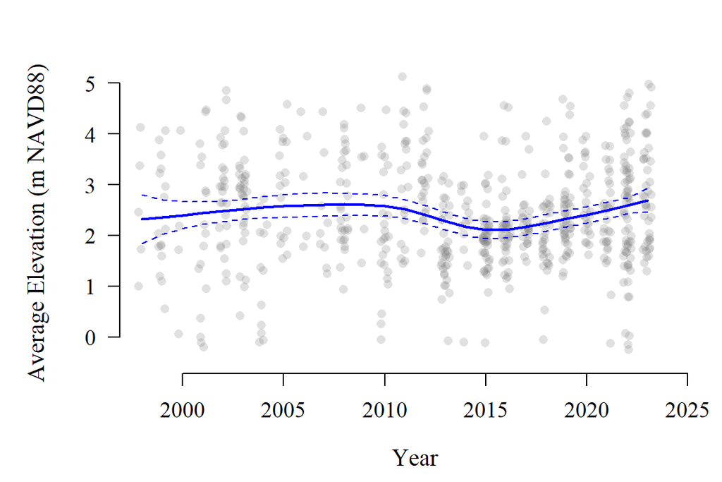

```
##
## Call:
## lm(formula = dem_avg ~ year, data = BHI_IncDur_Clean)
##
## Residuals:
##     Min      1Q  Median      3Q     Max
## -2.6568 -0.6537 -0.1396  0.6554  2.7110
##
## Coefficients:
##              Estimate Std. Error t value Pr(>|t|)
## (Intercept)  4.637950  11.281731   0.411    0.681
## year        -0.001103   0.005603  -0.197    0.844
##
## Residual standard error: 1.02 on 638 degrees of freedom
##   (395 observations deleted due to missingness)
## Multiple R-squared:  6.079e-05,  Adjusted R-squared:  -0.001507
## F-statistic: 0.03879 on 1 and 638 DF,  p-value: 0.8439
```

```
## [1] "Mean elevation 2003-2007: 2.51 m NAVD88, Projected incubation duration: 54.8 days"
```

```
## [1] "Mean elevation 2019-2023: 2.55 m NAVD88, Projected incubation duration: 54.8 days"
```

## 4.6 Clutch Size Exploration

Clutch sizes from undisturbed nests show no long-term trend. Changes in clutch size through time are unlikely to explain any part of the recent lengthening of incubation durations on Bald Head Island.

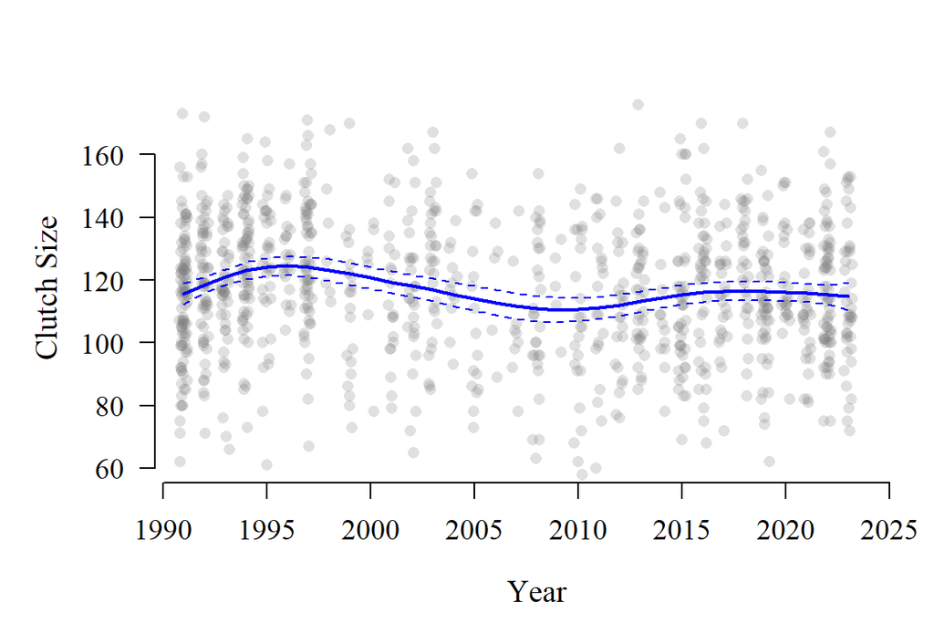

```
##
## Call:
## lm(formula = clutch_size ~ year, data = BHI_Undist_IncDur_Final)
##
## Residuals:
##     Min      1Q  Median      3Q     Max
## -56.244 -14.155  -1.453  14.620  61.452
##
## Coefficients:
##             Estimate Std. Error t value Pr(>|t|)
## (Intercept) -89.2773   297.9787  -0.300    0.765
## year          0.1013     0.1479   0.685    0.494
##
## Residual standard error: 21.3 on 568 degrees of freedom
## Multiple R-squared:  0.0008248,  Adjusted R-squared:  -0.0009343
## F-statistic: 0.4689 on 1 and 568 DF,  p-value: 0.4938
```

```
## [1] "Mean clutch size 2003-2007: 117.2 eggs, Projected incubation duration: 54.9 days"
```

```
## [1] "Mean clutch size 2019-2023: 114.6 eggs, Projected incubation duration: 54.9 days"
```

# 5 HATCHING SUCCESS

In the presented analysis, 986 nests (41.9%) were removed from the Bald Head Island loggerhead nest dataset due to relocation, predation, invasion by sea oat roots (*Uniola paniculata*), wave wash-over, wave wash-out, or missing hatching success data. No nests were reported to be scattered by another nesting female or poached. This left 1370 nests from 1991 - 2023 available for analysis.

Hatching success between *in situ* and relocated nests which were otherwise undisturbed were significantly different (Relocated nests HS -2.6%, p = 0.008, ES -4.4%, p < 0.001), hence the separation by relocation status mentioned above.

```
##  Family: beta  ( logit )
## Formula:          Hatch_Trans ~ in_situ_relocated
## Data: BHI_Undist_HsEs
##
##      AIC      BIC   logLik deviance df.resid
##  -1509.5  -1493.9    757.7  -1515.5     1306
##
##
## Dispersion parameter for beta family ():  3.3
##
## Conditional model:
##                            Estimate Std. Error z value Pr(>|z|)
## (Intercept)                 1.34974    0.03822   35.32  < 2e-16 ***
## in_situ_relocatedRelocated -0.15263    0.05739   -2.66  0.00783 **
## ---
## Signif. codes:  0 '***' 0.001 '**' 0.01 '*' 0.05 '.' 0.1 ' ' 1
```

```
##  in_situ_relocated response      SE  df asymp.LCL asymp.UCL
##  In situ              0.794 0.00625 Inf     0.782     0.806
##  Relocated            0.768 0.00857 Inf     0.751     0.784
##
## Confidence level used: 0.95
## Intervals are back-transformed from the logit scale
```

```
##  Family: beta  ( logit )
## Formula:          Emerge_Trans ~ in_situ_relocated
## Data: BHI_Undist_HsEs
##
##      AIC      BIC   logLik deviance df.resid
##  -1058.8  -1043.3    532.4  -1064.8     1306
##
##
## Dispersion parameter for beta family (): 3.02
##
## Conditional model:
##                            Estimate Std. Error z value Pr(>|z|)
## (Intercept)                 1.14166    0.03763  30.337  < 2e-16 ***
## in_situ_relocatedRelocated -0.22488    0.05798  -3.879 0.000105 ***
## ---
## Signif. codes:  0 '***' 0.001 '**' 0.01 '*' 0.05 '.' 0.1 ' ' 1
```

```
##  in_situ_relocated response      SE  df asymp.LCL asymp.UCL
##  In situ              0.758 0.00690 Inf     0.744     0.771
##  Relocated            0.714 0.00972 Inf     0.695     0.733
##
## Confidence level used: 0.95
## Intervals are back-transformed from the logit scale
```

```
##    vars    n mean   sd median trimmed mad min max range  skew kurtosis   se
## X1    1 1370 0.78 0.27   0.89    0.84 0.1   0   1     1 -1.85     2.27 0.01
```

```
##    vars    n mean   sd median trimmed  mad min max range  skew kurtosis   se
## X1    1 1370 0.75 0.28   0.87    0.81 0.12   0   1     1 -1.67     1.58 0.01
```

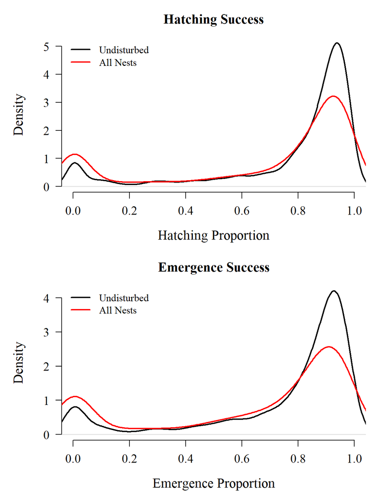

Hatching success is variable from year to year. Observed annual mean hatching success has ranged from 51.6% $\pm$ 37.5% (1995) to 93.6% $\pm$ 7.5% in 2007. The 2023 average was 89.2% $\pm$ 9.4%.

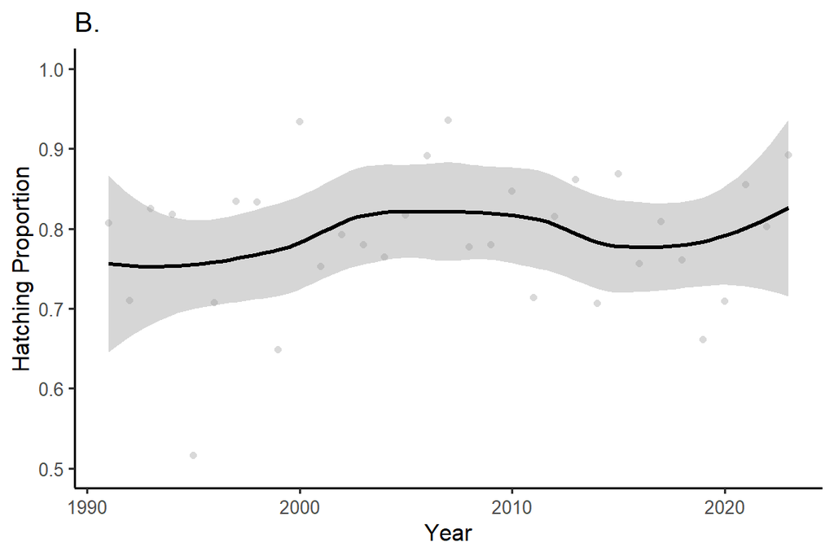

Average hatching success on Bald Head Island by year

| year | mean | sd | n |
| --- | --- | --- | --- |
| 1991 | 0.807 | 0.237 | 113 |
| 1992 | 0.710 | 0.292 | 78 |
| 1993 | 0.825 | 0.244 | 52 |
| 1994 | 0.818 | 0.218 | 74 |
| 1995 | 0.516 | 0.375 | 64 |
| 1996 | 0.707 | 0.335 | 29 |
| 1997 | 0.834 | 0.203 | 66 |
| 1998 | 0.833 | 0.191 | 13 |
| 1999 | 0.648 | 0.335 | 29 |
| 2000 | 0.934 | 0.028 | 21 |
| 2001 | 0.753 | 0.296 | 34 |
| 2002 | 0.792 | 0.278 | 61 |
| 2003 | 0.780 | 0.261 | 42 |
| 2004 | 0.764 | 0.292 | 16 |
| 2005 | 0.817 | 0.208 | 21 |
| 2006 | 0.891 | 0.111 | 5 |
| 2007 | 0.936 | 0.075 | 10 |
| 2008 | 0.777 | 0.309 | 37 |
| 2009 | 0.780 | 0.345 | 6 |
| 2010 | 0.847 | 0.162 | 40 |
| 2011 | 0.714 | 0.302 | 29 |
| 2012 | 0.815 | 0.269 | 40 |
| 2013 | 0.861 | 0.197 | 43 |
| 2014 | 0.706 | 0.291 | 15 |
| 2015 | 0.869 | 0.160 | 54 |
| 2016 | 0.756 | 0.252 | 52 |
| 2017 | 0.809 | 0.271 | 33 |
| 2018 | 0.761 | 0.280 | 35 |
| 2019 | 0.661 | 0.372 | 74 |
| 2020 | 0.709 | 0.320 | 29 |
| 2021 | 0.855 | 0.139 | 35 |
| 2022 | 0.802 | 0.264 | 75 |
| 2023 | 0.892 | 0.094 | 45 |

Year is a significant variable with respect to hatching success, but it is a poor descriptor as Year alone only explains 26.7% of the observed variance.

*Beta GAM*, $Duration = \beta_0 + f(Year) + \epsilon$

```
##
## Family: Beta regression(1.264)
## Link function: logit
##
## Formula:
## Hatch_Trans ~ s(year)
##
## Parametric coefficients:
##             Estimate Std. Error z value Pr(>|z|)
## (Intercept)  0.64314    0.03254   19.76   <2e-16 ***
## ---
## Signif. codes:  0 '***' 0.001 '**' 0.01 '*' 0.05 '.' 0.1 ' ' 1
##
## Approximate significance of smooth terms:
##           edf Ref.df Chi.sq  p-value
## s(year) 6.659  7.757  38.14 4.06e-07 ***
## ---
## Signif. codes:  0 '***' 0.001 '**' 0.01 '*' 0.05 '.' 0.1 ' ' 1
##
## R-sq.(adj) =  0.0187   Deviance explained = 26.7%
## -REML = -543.66  Scale est. = 1         n = 1370
```

## 5.1 Five-Year Averages

To help smooth out this variability, 5-year moving averages are presented below.

5-Year Averages of Incubation Durations, Hatchling Production, and Meteorology on Bald Head Island

| Year Start | Year End | Mean Duration | SD Duration | Mean HS | SD HS | Mean ES | SD ES | Mean Avg Temp | SD Avg Temp | Mean Max Temp | SD Max Temp | Mean Total Rain | SD Total Rain |
| --- | --- | --- | --- | --- | --- | --- | --- | --- | --- | --- | --- | --- | --- |
| 1991 | 1995 | 59.6 | 5.0 | 0.743 | 0.294 | 0.743 | 0.294 | NA | NA | 27.7 | 0.9 | NA | NA |
| 1992 | 1996 | 60.2 | 5.4 | 0.715 | 0.313 | 0.715 | 0.313 | NA | NA | 27.5 | 0.9 | NA | NA |
| 1993 | 1997 | 59.9 | 5.3 | 0.744 | 0.302 | 0.744 | 0.302 | NA | NA | 27.4 | 0.9 | NA | NA |
| 1994 | 1998 | 60.5 | 5.4 | 0.731 | 0.306 | 0.731 | 0.306 | NA | NA | 27.3 | 0.7 | NA | NA |
| 1995 | 1999 | 59.2 | 5.4 | 0.687 | 0.331 | 0.687 | 0.331 | NA | NA | 27.5 | 0.8 | NA | NA |
| 1996 | 2000 | 59.6 | 5.0 | 0.790 | 0.262 | 0.790 | 0.262 | NA | NA | 27.4 | 0.8 | NA | NA |
| 1997 | 2001 | 59.5 | 4.9 | 0.797 | 0.253 | 0.797 | 0.253 | NA | NA | 27.4 | 0.9 | NA | NA |
| 1998 | 2002 | 58.8 | 5.0 | 0.779 | 0.279 | 0.779 | 0.279 | NA | NA | 28.0 | 1.4 | NA | NA |
| 1999 | 2003 | 59.1 | 4.8 | 0.776 | 0.279 | 0.770 | 0.280 | NA | NA | 28.4 | 1.7 | NA | NA |
| 2000 | 2004 | 59.7 | 4.2 | 0.796 | 0.265 | 0.784 | 0.269 | NA | NA | 28.7 | 1.7 | NA | NA |
| 2001 | 2005 | 58.7 | 4.4 | 0.782 | 0.269 | 0.757 | 0.280 | NA | NA | 29.1 | 1.6 | NA | NA |
| 2002 | 2006 | 57.7 | 4.2 | 0.792 | 0.260 | 0.758 | 0.273 | 26.9 | 1.3 | 29.6 | 1.2 | 102.0 | 101.1 |
| 2003 | 2007 | 57.5 | 4.7 | 0.808 | 0.239 | 0.750 | 0.260 | 26.4 | 1.6 | 29.1 | 1.4 | 103.8 | 97.6 |
| 2004 | 2008 | 56.4 | 4.3 | 0.809 | 0.260 | 0.737 | 0.296 | 26.1 | 1.4 | 29.4 | 1.6 | 133.7 | 80.4 |
| 2005 | 2009 | 55.5 | 3.7 | 0.815 | 0.259 | 0.748 | 0.295 | 26.1 | 1.4 | 29.5 | 1.7 | 152.0 | 66.1 |
| 2006 | 2010 | 54.8 | 3.7 | 0.828 | 0.237 | 0.752 | 0.279 | 26.2 | 1.4 | 29.6 | 1.6 | 123.5 | 41.8 |
| 2007 | 2011 | 55.2 | 4.0 | 0.798 | 0.260 | 0.729 | 0.299 | 26.6 | 1.2 | 30.0 | 1.3 | 157.8 | 111.9 |
| 2008 | 2012 | 55.3 | 3.9 | 0.794 | 0.267 | 0.727 | 0.305 | 26.7 | 1.0 | 30.1 | 1.1 | 177.7 | 118.4 |
| 2009 | 2013 | 56.0 | 4.5 | 0.816 | 0.240 | 0.747 | 0.279 | 26.6 | 0.9 | 29.6 | 0.8 | 199.2 | 117.6 |
| 2010 | 2014 | 56.2 | 4.5 | 0.807 | 0.243 | 0.732 | 0.283 | 26.5 | 1.0 | 29.5 | 0.9 | 217.9 | 121.2 |
| 2011 | 2015 | 55.9 | 4.9 | 0.817 | 0.239 | 0.749 | 0.272 | 26.7 | 1.1 | 29.8 | 1.1 | 220.5 | 123.4 |
| 2012 | 2016 | 55.4 | 5.2 | 0.816 | 0.231 | 0.749 | 0.254 | 27.1 | 1.3 | 30.3 | 1.4 | 215.8 | 101.3 |
| 2013 | 2017 | 55.7 | 5.2 | 0.815 | 0.230 | 0.754 | 0.247 | 27.3 | 1.2 | 30.5 | 1.3 | 213.2 | 100.2 |
| 2014 | 2018 | 55.2 | 5.0 | 0.794 | 0.246 | 0.742 | 0.255 | 27.5 | 1.1 | 30.8 | 1.2 | 233.5 | 112.3 |
| 2015 | 2019 | 55.7 | 5.0 | 0.760 | 0.293 | 0.714 | 0.300 | 27.6 | 0.8 | 31.0 | 0.8 | 213.5 | 97.4 |
| 2016 | 2020 | 56.7 | 4.6 | 0.727 | 0.314 | 0.690 | 0.319 | 27.7 | 0.9 | 31.1 | 0.9 | 219.9 | 94.2 |
| 2017 | 2021 | 58.2 | 3.9 | 0.741 | 0.310 | 0.715 | 0.320 | 27.5 | 0.7 | 31.0 | 0.8 | 220.2 | 91.2 |
| 2018 | 2022 | 58.1 | 4.0 | 0.751 | 0.303 | 0.721 | 0.315 | 27.5 | 0.7 | 30.9 | 0.7 | 225.6 | 82.4 |
| 2019 | 2023 | 57.6 | 4.2 | 0.774 | 0.287 | 0.743 | 0.304 | 27.5 | 0.7 | 30.9 | 0.8 | 207.5 | 72.8 |

## 5.2 Hatching Success ~ f(Meteorological, Behavioral, and Maternal Variables)

To test which meteorological variables are important drivers of hatching success, a nested model selection approach using AICc was employed. The full GAM includes average daily mean air temperature and average total precipitation experienced during incubation, as well as Year, Day Laid, Distance from the Ferry Port, Distance from the Dune Toe, Elevation, Clutch Size, and Maternal Identity as additional covariates:

*Beta GAM*,  
$Hs = \beta_0 + f_1(Air_{avg,i}) + f_2(Precip_i) + f_3(Year_i) + f_4(DayLaid_i) + f_5(DistFerry_i) +$  
$f_6(DistDune_i) + f_7(Elevation_i) + f_8(ClutchSize_i) + \beta_1(FemaleID_i) + \epsilon_i$

634 nests include observations for each of these variables. The best model includes total precipitation, year and day laid, elevation, and clutch size, but it only explains 33% of the deviance. Removing any of the variables results in a significant increase in AICc.

```
## Global model call: mgcv::gam(formula = Hatch_Trans ~ s(mean_avg_air) + s(total_precip) +
##     s(year) + s(day_laid) + s(beach_distance_m) + s(dist_dune) +
##     s(dem_avg) + s(clutch_size) + factor(turtle_id), family = betar(link = "logit"),
##     data = BHI_Undist_HsEs_Full, na.action = "na.fail")
## ---
## Model selection table
##      (Int) s(bch_dstn_m) s(clt_siz) s(day_lad) s(dem_avg) s(dist_dun)
## 413 0.8544                        +          +          +
## 429 0.8545                        +          +                      +
## 431 0.8557             +          +          +                      +
## 415 0.8549             +          +          +          +
## 477 0.8554                        +          +          +
## 493 0.8556                        +          +                      +
## 445 0.8549                        +          +          +           +
## 409 0.8529                                   +          +
```

[output cut: 60 more lines]

*Potential issue with low sample size in 2002 (n = 6), 2006 (n = 5), 2007 (n = 9), and 2009 (n = 5)*

```
##
## Family: Beta regression(1.696)
## Link function: logit
##
## Formula:
## Hatch_Trans ~ s(total_precip) + s(year) + s(day_laid) + s(dem_avg) +
##     s(clutch_size)
##
## Parametric coefficients:
##             Estimate Std. Error z value Pr(>|z|)
## (Intercept)  0.84506    0.04511   18.73   <2e-16 ***
## ---
## Signif. codes:  0 '***' 0.001 '**' 0.01 '*' 0.05 '.' 0.1 ' ' 1
##
## Approximate significance of smooth terms:
##                   edf Ref.df Chi.sq  p-value
## s(total_precip) 1.001  1.001 16.439 5.13e-05 ***
## s(year)         6.004  7.122 32.177 3.61e-05 ***
## s(day_laid)     3.385  4.248 29.044 1.31e-05 ***
## s(dem_avg)      1.000  1.000  3.605   0.0576 .
## s(clutch_size)  2.770  3.512  6.232   0.1242
## ---
## Signif. codes:  0 '***' 0.001 '**' 0.01 '*' 0.05 '.' 0.1 ' ' 1
##
## R-sq.(adj) =  0.089   Deviance explained = 33.1%
## -REML = -288.56  Scale est. = 1         n = 634
```

Number of nests included in the above model per year

| Var1 | Freq |
| --- | --- |
| 2002 | 6 |
| 2003 | 34 |
| 2004 | 14 |
| 2005 | 17 |
| 2006 | 5 |
| 2007 | 9 |
| 2008 | 29 |
| 2009 | 5 |
| 2010 | 29 |
| 2011 | 20 |
| 2012 | 29 |
| 2013 | 38 |
| 2014 | 15 |
| 2015 | 47 |
| 2016 | 40 |
| 2017 | 31 |
| 2018 | 32 |
| 2019 | 63 |
| 2020 | 28 |
| 2021 | 32 |
| 2022 | 68 |
| 2023 | 43 |

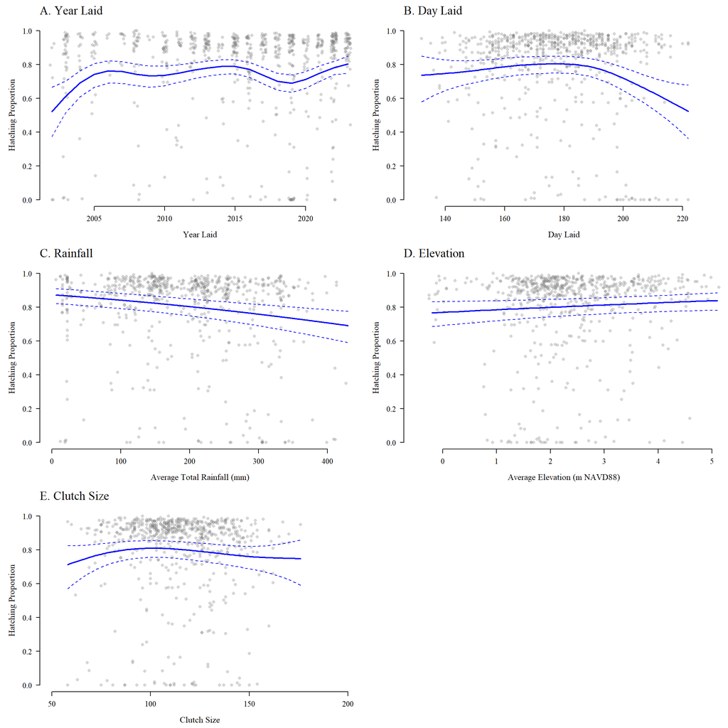

When scaled in a linear model for a more simple effect size comparison, total precipitation has the strongest scaled effect (-0.230), followed by day laid (-0.121) and year (0.108). Elevation and clutch have weak scaled effects which 95% confidence interval significantly overlaps 0.

```
##                2.5 % 97.5 % Estimate
## (Intercept)  -70.713  3.432  -33.640
## total_precip  -0.004 -0.001   -0.002
## year           0.000  0.036    0.018
## day_laid      -0.012 -0.001   -0.007
## dem_avg       -0.025  0.154    0.065
## clutch_size   -0.007  0.002   -0.003
```

```
##                      2.5 % 97.5 % Estimate
## (Intercept)          0.714  0.913    0.814
## scale(total_precip) -0.341 -0.118   -0.230
## scale(year)         -0.003  0.218    0.108
## scale(day_laid)     -0.220 -0.023   -0.121
## scale(dem_avg)      -0.025  0.155    0.065
## scale(clutch_size)  -0.160  0.034   -0.063
```

## 5.3 Rainfall Exploration

Rainfall has significantly increased on the island since 2002. All else being equal, the increased rainfall could result in a decrease in hatching success of up to 5.8%.

```
## [1] "Mean rainfall 2003-2007: 71.9 mm, Projected hatching success: 0.851"
```

```
## [1] "Mean rainfall 2019-2023: 224.3 mm, Projected hatching success: 0.793"
```

## 5.4 Day Laid Exploration

The average deposition date of undisturbed nests has trended 0.217 days yr<sup>-1</sup> earlier since 2002. This trend has no effect on hatching success on Bald Head Island.

```
## [1] "Mean day laid 2003-2007: 180.3, Projected hatching success: 0.806"
```

```
## [1] "Mean day laid 2019-2023: 176.9, Projected hatching success: 0.806"
```

## 5.5 Elevation Exploration

Nest elevation, based on the time-average DEM from 1998 - 2020, shows no long-term trend or significant effect on hatching success.

```
## [1] "Mean elevation 2003-2007: 2.47 m NAVD88, Projected hatching success: 0.809"
```

```
## [1] "Mean elevation 2019-2023: 2.52 m NAVD88, Projected incubation duration: 0.809"
```

## 5.6 Clutch Size Exploration

Clutch sizes from undisturbed nests show no long-term trend since 2002. Changes in clutch size through time are unlikely to explain any part of the recent lengthening of incubation durations on Bald Head Island.

```
## [1] "Mean clutch size 2003-2007: 117.9 eggs, Projected hatching success: 0.803"
```

```
## [1] "Mean clutch size 2019-2023: 114.4 eggs, Projected hatching success: 0.806"
```

# 6 References

```
## Analyses were conducted using the R Statistical language
## (version 4.3.2; R Core Team, 2023) on Windows 10 x64 (build
## 19045), using the packages MuMIn (version 1.47.5; Bartoń K,
## 2023), glmmTMB (version 1.1.8; Brooks ME et al., 2017),
## janitor (version 2.2.0; Firke S, 2023), DHARMa (version
## 0.4.6; Hartig F, 2022), emmeans (version 1.9.0; Lenth R,
## 2023), report (version 0.5.8; Makowski D et al., 2023),
## nlme (version 3.1.164; Pinheiro J et al., 2023),
## datetimeutils (version 0.6.3; Schumann E, 2023), ggplot2
## (version 3.4.4; Wickham H, 2016), readxl (version 1.4.3;
## Wickham H, Bryan J, 2023), dplyr (version 1.1.4; Wickham H
## et al., 2023), psych (version 2.3.12; William Revelle,
## 2023), mgcv (version 1.9.1; Wood SN, 2011) and knitr
## (version 1.45; Xie Y, 2023).
##
## References
## ----------
##   - Bartoń K (2023). _MuMIn: Multi-Model Inference_. R
## package version 1.47.5,
## <https://CRAN.R-project.org/package=MuMIn>.
##   - Brooks ME, Kristensen K, van Benthem KJ, Magnusson A,
## Berg CW, Nielsen A, Skaug HJ, Maechler M, Bolker BM (2017).
## "glmmTMB Balances Speed and Flexibility Among Packages for
## Zero-inflated Generalized Linear Mixed Modeling." _The R
## Journal_, *9*(2), 378-400. doi:10.32614/RJ-2017-066
## <https://doi.org/10.32614/RJ-2017-066>.
##   - Firke S (2023). _janitor: Simple Tools for Examining and
## Cleaning Dirty Data_. R package version 2.2.0,
## <https://CRAN.R-project.org/package=janitor>.
##   - Hartig F (2022). _DHARMa: Residual Diagnostics for
## Hierarchical (Multi-Level / Mixed) Regression Models_. R
## package version 0.4.6,
## <https://CRAN.R-project.org/package=DHARMa>.
##   - Lenth R (2023). _emmeans: Estimated Marginal Means, aka
## Least-Squares Means_. R package version 1.9.0,
## <https://CRAN.R-project.org/package=emmeans>.
##   - Makowski D, Lüdecke D, Patil I, Thériault R, Ben-Shachar
## M, Wiernik B (2023). "Automated Results Reporting as a
## Practical Tool to Improve Reproducibility and
## Methodological Best Practices Adoption." _CRAN_.
```

[output cut: 36 more lines]

```
## *99*(467), 673-686. Wood S (2017). _Generalized Additive
## Models: An Introduction with R_, 2 edition. Chapman and
## Hall/CRC. Wood SN (2003). "Thin-plate regression splines."
## _Journal of the Royal Statistical Society (B)_, *65*(1),
## 95-114.
##   - Xie Y (2023). _knitr: A General-Purpose Package for
## Dynamic Report Generation in R_. R package version 1.45,
## <https://yihui.org/knitr/>. Xie Y (2015). _Dynamic
## Documents with R and knitr_, 2nd edition. Chapman and
## Hall/CRC, Boca Raton, Florida. ISBN 978-1498716963,
## <https://yihui.org/knitr/>. Xie Y (2014). "knitr: A
## Comprehensive Tool for Reproducible Research in R." In
## Stodden V, Leisch F, Peng RD (eds.), _Implementing
## Reproducible Computational Research_. Chapman and Hall/CRC.
## ISBN 978-1466561595.
```